# Pan-cancer_cell_line_heterogeneity

Daniel Hanhart

11/18/2022

## R Markdown

Scientific question: What type of signaling is commonly occurring inside cancer cell line and PDX models?

### Pan-Cancer data

```r
#sobj <- readRDS("/home/triller/Desktop/Projects/Pan-cancer_cell_line_heterogeneity/pan_cancer_heterogeneity/SERSI/run_all_samples/results/Pan_cancer/Annotation/scMRMA/SeuratObject.rds")
#saveRDS(sobj,file = "./../local/SeuratObject.rds")

sobj <- readRDS("./../local/SeuratObject.rds")

## add Cancer types to data
cancer_type_mapping <- readRDS("./../local/cancer_type_mapping.rds")
df_mapped <- data.frame(Cell_line = sobj@meta.data$cell_line)
# first add index to colum (1:nbr of cancer types) so the merged results can later be sorted by that index, prevents that order gets mixed up
df_mapped <- cbind(df_mapped, data.frame(ID = 1:nrow(df_mapped))) %>% merge(cancer_type_mapping, by = "Cell_line", all.x = TRUE, sort = FALSE ) %>% arrange(ID)
# assign cancer type to each cell line
sobj@meta.data$Cancer_type <-  df_mapped$Cancer_type
```

#### overview of all the data

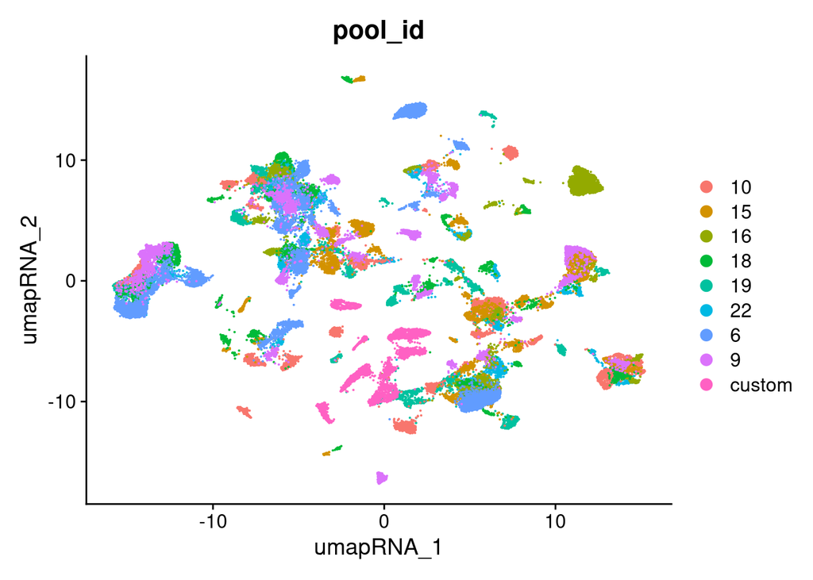

```r
DimPlot(sobj, group.by = "pool_id", reduction = "umap_RNA", label = FALSE)
```

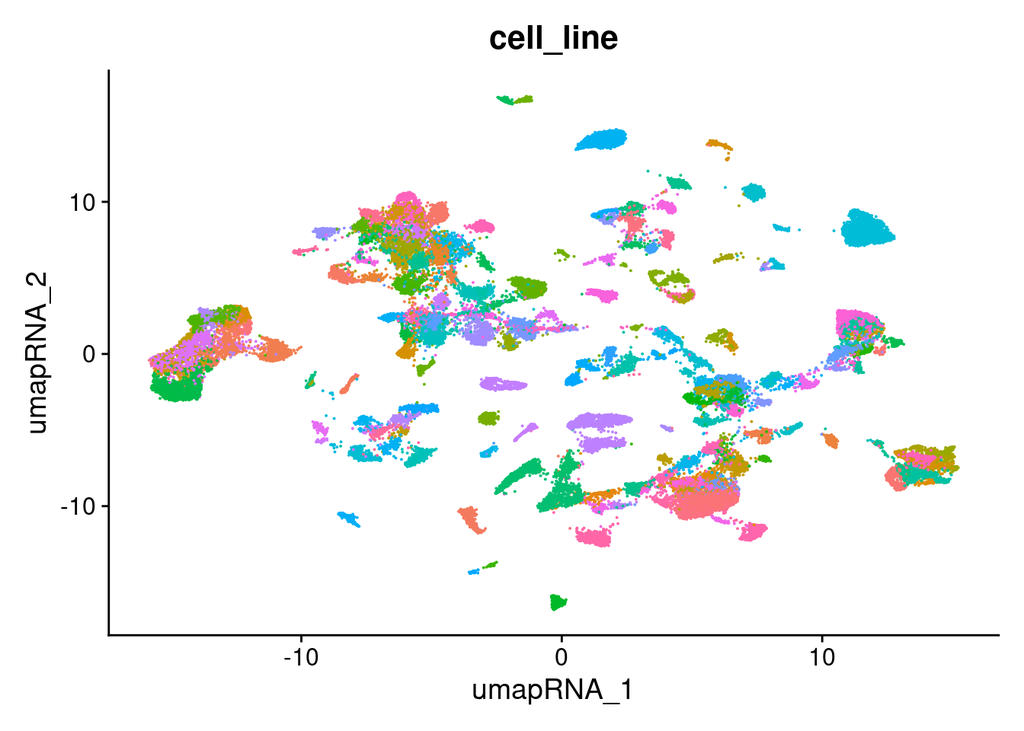

```r
DimPlot(sobj, group.by = "cell_line", reduction = "umap_RNA", label = FALSE) + theme(legend.position = "none")
```

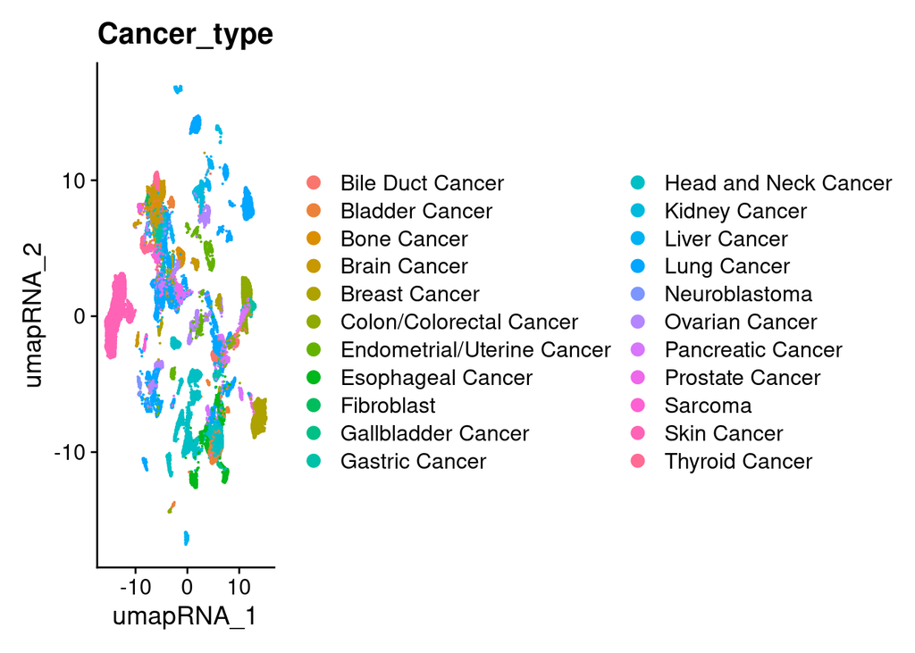

```r
DimPlot(sobj, group.by = "Cancer_type", reduction = "umap_RNA", label = FALSE)
```

#### amount of cells by pool and cancer type

```r
metadata <- sobj@meta.data %>% group_by(pool_id, Cancer_type, cell_line) %>% summarise(nbr_of_cells = n())
```

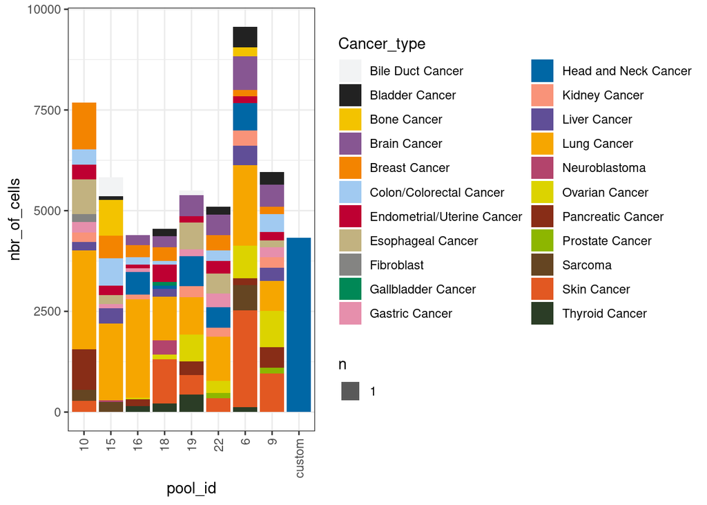

```r
p <- ggplot(metadata, aes(x = pool_id , y = nbr_of_cells, fill = Cancer_type )) +
    geom_bar(stat = "sum", position = "stack")  + theme_bw() + scale_fill_manual(values=c(kelly()[1:length(kelly())])) + theme(axis.text.x = element_text(angle = 90, vjust = 0.5, hjust=1))
#    facet_grid(.~subtype, scale = "free", space = "free") + labs(title = lev)+ facet_grid(.~pool_id, drop = TRUE, scales = "free", space = "fixed")+ theme(legend.position = "none")
p
```

#### amount of cells by cancer type

```r
metadata <- sobj@meta.data %>% group_by(pool_id, Cancer_type, cell_line) %>% summarise(nbr_of_cells = n())
```

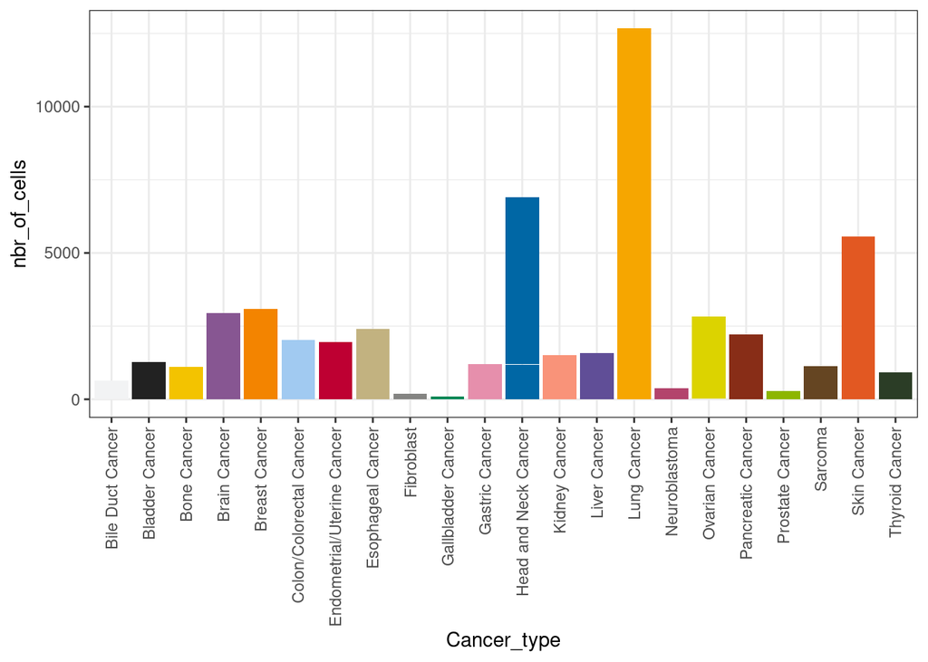

```r
p <- ggplot(metadata, aes(x = Cancer_type , y = nbr_of_cells, fill = Cancer_type )) +
    geom_bar(stat = "sum", position = "stack")  + theme_bw() + scale_fill_manual(values=c(kelly()[1:length(kelly())])) + theme(axis.text.x = element_text(angle = 90, vjust = 0.5, hjust=1)) + theme(legend.position = "none")
#    facet_grid(.~subtype, scale = "free", space = "free") + labs(title = lev)+ facet_grid(.~pool_id, drop = TRUE, scales = "free", space = "fixed")+ theme(legend.position = "none")
p
```

#### some basic quality featuers

[output not shown]

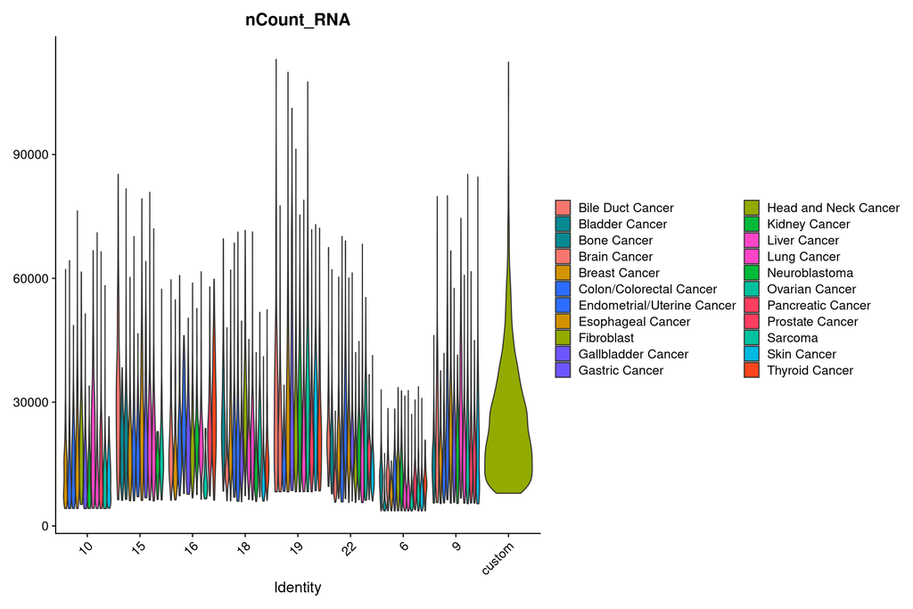

```r
DefaultAssay(sobj) <- "RNA"
 VlnPlot(sobj, features = "nCount_RNA", pt.size = 0, group.by = "pool_id", split.by = "Cancer_type")
```

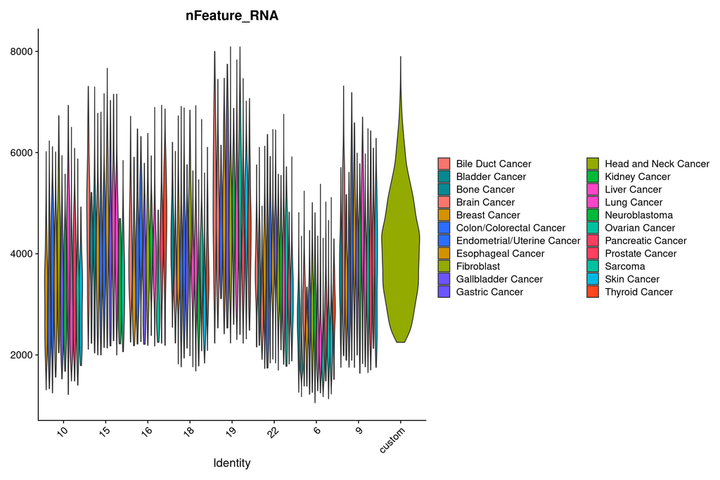

```r
 VlnPlot(sobj, features = "nFeature_RNA", pt.size = 0, group.by = "pool_id", split.by = "Cancer_type")
```

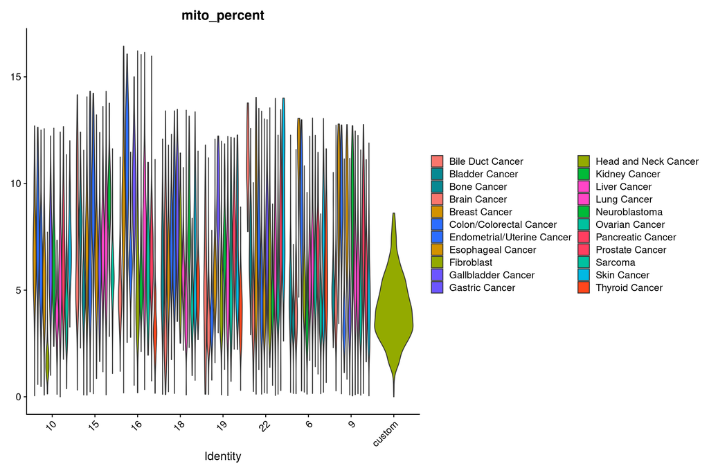

```r
 VlnPlot(sobj, features = "mito_percent", pt.size = 0, group.by = "pool_id", split.by = "Cancer_type")
```

## SingleCellSingalR with omnipathr

Overlap between the omni and LRdb is not optimal! overall there seem to be more unique communication found in omni compared to LRdb

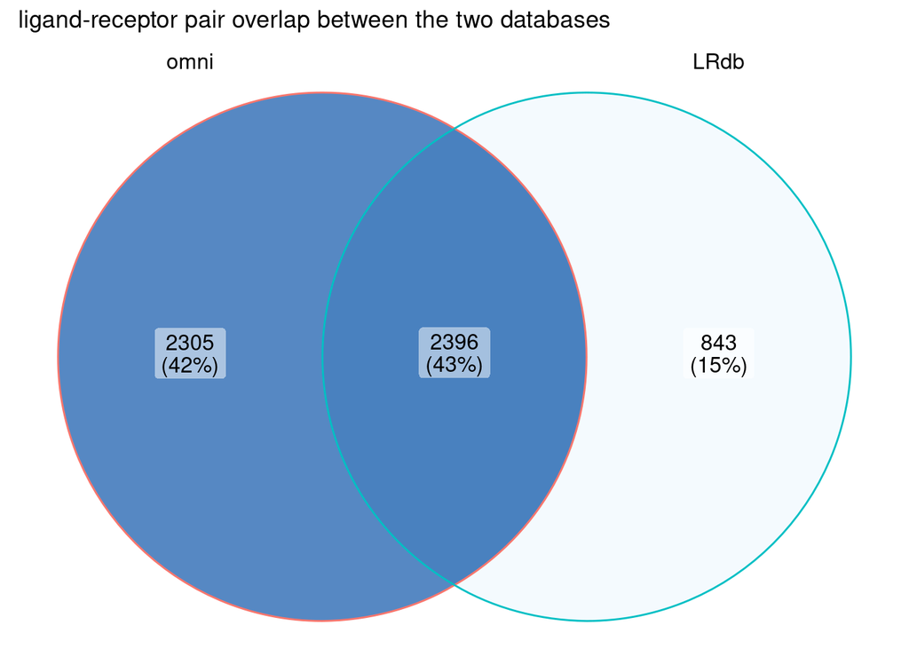

```r
# ## Omnipather
library(OmnipathR)

omni_DB <- liana::select_resource("Consensus")[[1]]

omni_DB <- omni_DB %>% mutate(ligand = source_genesymbol, receptor = target_genesymbol) %>% relocate(ligand, receptor)

original_DB <- LRdb


ID_1 <- unique(paste0(omni_DB$ligand, "_", omni_DB$receptor))
ID_2 <- unique(paste0(original_DB$ligand, "_", original_DB$receptor))

ggVennDiagram(list(omni = ID_1, LRdb = ID_2), color = 1, lwd = 0.7) +
 scale_fill_gradient(low = "#F4FAFE", high = "#4981BF") +
 theme(legend.position = "none") + ggtitle("ligand-receptor pair overlap between the two databases")
```

```r
# clean up
rm(ID_1, ID_2, original_DB)
```

```r
## get autocrine signalings
DefaultAssay(sobj) <- "RNA"

# Cell_line_mapping <- data.frame(cell_line = unique(sobj@meta.data$cell_line))
# Cell_line_mapping$cell_line_nbr <- 1:nrow(Cell_line_mapping)
#
# Cell_line_mapped <- data.frame(cell_line = sobj@meta.data$cell_line)
# Cell_line_mapped$ID <- 1:nrow(Cell_line_mapped)
# Cell_line_mapped <- Cell_line_mapped %>% merge(Cell_line_mapping, by = "cell_line") %>% arrange(ID)
# sobj@meta.data$Cell_line_ID <- Cell_line_mapped$cell_line_nbr

if(FALSE){
  ## make for loop over all cell lines (full data to big)
  res_list <- list()
  for(i in unique(sobj@meta.data$cell_line)){
    print(i)
    object <- subset(sobj, cell_line == i)
    ## get cancer type
    ct <- unique(object@meta.data$Cancer_type)
    #cluster = object@meta.data$Cell_line_ID
    cluster = rep(1, length(object$cell_line))
    data=data.frame(object[['RNA']]@data)
    ## set s.score to 0 to keep all results, better for robust rank aggregation

  ## overwrite LRdb ressource, so the custom ressourse is used
    LRdb <- omni_DB
    signal=cell_signaling(data=data,
                          genes=row.names(object),
                          cluster=cluster,
                          int.type = "autocrine",
                          species = "homo sapiens",
                          s.score = 0, write = FALSE)
    signal <- as.data.frame(unlist(signal, recursive = FALSE)) %>% mutate(Cell_line = i, Cancer_type = ct)

    res_list[[i]] <- signal

  }
  saveRDS(res_list, "./../local/signal_list_omni.rds")
}

################################################################################

res_list <- readRDS("./../local/signal_list_omni.rds")

res <- do.call(rbind, res_list) %>% remove_rownames(.) %>% dplyr::rename(
  ligand = cluster.1.cluster.1.cluster.1,
  receptor = cluster.1.cluster.1.cluster.1.1,
  score = cluster.1.cluster.1.LRscore, type = cluster.1.cluster.1.interaction.type) %>% mutate(ID = paste0(ligand, "_", receptor))

## summarise amount of autocrine signaling based on cell line

DF_stats <- res %>% filter(score >= 0.5) %>% group_by(Cell_line, Cancer_type) %>% summarise(n = n())
DT::datatable(DF_stats)
```

|  | Cell_line | Cancer_type | n |
| --- | --- | --- | --- |
| 1 | 2313287_STOMACH | Gastric Cancer | 112 |
| 2 | 42MGBA_CENTRAL_NERVOUS_SYSTEM | Brain Cancer | 204 |
| 3 | 8305C_THYROID | Thyroid Cancer | 286 |
| 4 | 93VU_UPPER_AERODIGESTIVE_TRACT | Head and Neck Cancer | 190 |
| 5 | A204_SOFT_TISSUE | Sarcoma | 184 |
| 6 | A2058_SKIN | Skin Cancer | 173 |
| 7 | A375_SKIN | Skin Cancer | 150 |
| 8 | ABC1_LUNG | Lung Cancer | 181 |
| 9 | ACCMESO1_PLEURA | Lung Cancer | 185 |
| 10 | ASPC1_PANCREAS | Pancreatic Cancer | 222 |

[output cut: 197 more lines]

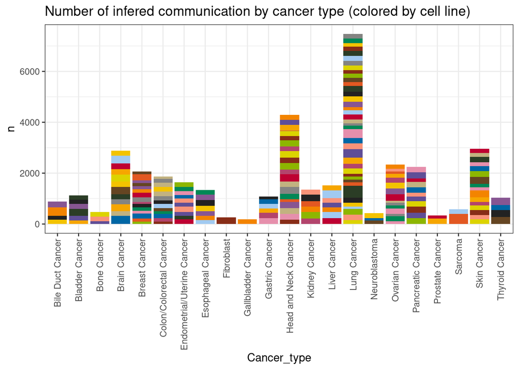

```r
ggplot(DF_stats, aes(Cancer_type ,n, fill = Cell_line)) +
    geom_bar(stat = "sum", position = "stack") + theme_bw() +
    theme(axis.text.x = element_text(angle = 90, vjust = 0.5, hjust=1),
          legend.position = "none") +
    scale_fill_manual(values=c(rep(kelly()[2:length(kelly())], 20))) +
    labs(title = "Number of infered communication by cancer type (colored by cell line)")
```

```r
## create overlap matrix between all cell lines
# cell_lines <- unique(res$Cell_line)
# overlap_mtx <- matrix(ncol = length(cell_lines), nrow = length(cell_lines))
# rownames(overlap_mtx) <- cell_lines
# colnames(overlap_mtx) <- cell_lines
#
# for(n in seq_along(cell_lines)){
#   i <- cell_lines[n]
#   print(paste0(i, " : ", n))
#   r_1 <- res %>% filter(score >= 0.5) %>% filter(Cell_line == i)
#   for(j in cell_lines){
#     r_2 <- res %>% filter(score >= 0.5) %>% filter(Cell_line == j)
#     ratio <- (sum(r_1$ID %in% r_2$ID) / length(unique(c(r_1$ID, r_2$ID))))
#     overlap_mtx[i,j] <- ratio
#   }
# }
#
# overlap_df_2 <- overlap_mtx %>% as.data.frame()
#
# # add cancer type do df
# b <- res %>% select(Cell_line, Cancer_type) %>% distinct()
# Cancer_type_mapping <- b$Cancer_type
# names(Cancer_type_mapping) <- b$Cell_line
#
#
# ann <- data.frame( row.names = rownames(overlap_df_2), Cancer_type = unlist(sapply(rownames(overlap_df_2), simplify = FALSE, USE.NAMES = FALSE, function(x){Cancer_type_mapping[x]})))
# or <- order(ann$Cancer_type)
# overlap_df_2 <- overlap_df_2[or, or]
# ann <- data.frame( row.names = rownames(overlap_df_2), Cancer_type = unlist(sapply(rownames(overlap_df_2), simplify = FALSE, USE.NAMES = FALSE, function(x){Cancer_type_mapping[x]})))
# ## save as svg, because heatmap is big
# ggsave(plot = pheatmap(overlap_df_2, annotation_row = ann, annotation_col = ann, cluster_rows = FALSE, cluster_cols = FALSE,fontsize = 3),
#        filename = "heatmap.svg",
#        device = "svg",
#        width = 10,
#        height = 10)


aggregate_ranks <- function(ranked_list){
    # aggregate ranks
    agg_ranks <- aggregateRanks(ranked_list, method = "RRA")
    rownames(agg_ranks) <- NULL
    # correct for multiple testing  doi:10.1093/bioinformatics/btr709.
    # The initial create scores ar minimal bounds for p-values, Bonferroni correct by multiplby scores * length(ranked_list) to get upper bound.
    # Then correct for multiple testing for each performed test (ID)
    agg_ranks$Score.adj <- agg_ranks$Score * length(ranked_list)
    agg_ranks$Score.adj <- p.adjust(agg_ranks$Score.adj, "BH")
    agg_ranks <- agg_ranks %>% dplyr::rename(ID = Name)
    return(agg_ranks)
}
```

#### all cancer types/lines

```r
#### aggregate results over all cell lines (find commonly found communications in cancer)
ranked_list <- lapply(setNames(unique(res$Cell_line),unique(res$Cell_line)), function(i){
  r <- res %>% filter(Cell_line == i) %>% arrange(desc(score));
  unique(r$ID)
})

aggregation_res <- aggregate_ranks(ranked_list) %>% arrange(Score.adj, Score)
## add rank to results
aggregation_res <- aggregation_res %>% mutate(rank = 1:nrow(aggregation_res))

## merge back together initial results with aggregation rank
agg_res <- merge(res, aggregation_res, by = "ID" , all = TRUE)
# remove non significant results
agg_res <- agg_res %>% filter(Score.adj < 0.05) %>% group_by(ID, ligand, receptor, type, Score, Score.adj, rank) %>% summarise(mean_score = mean(score)) %>%  arrange(Score.adj, Score,  desc(mean_score))
```

```
## 'Score', 'Score.adj'. You can override using the `.groups` argument.
```

```r
#n_Cancer_types = length(unique(Cancer_type)), n_Cell_lines = length(unique(Cell_line)), Cancer_types = toString(unique(Cancer_type), collapse = ",") , Cell_lines = toString(unique(Cell_line), collapse = ",") # not useful here
# additionally remove results where the mean score is below the 0.5 threshold, resulting in a list of signals found across cancer lines
agg_res <- agg_res %>% filter(mean_score > 0.5)

## aggregation results all
DT::datatable(agg_res)
```

|  | ID | ligand | receptor | type | Score | Score.adj | rank | mean_score |
| --- | --- | --- | --- | --- | --- | --- | --- | --- |
| 1 | LGALS1_ITGB1 | LGALS1 | ITGB1 | autocrine | 0 | 0 | 1 | 0.866959095311612 |
| 2 | TIMP1_CD63 | TIMP1 | CD63 | autocrine | 0 | 0 | 5 | 0.850003000551904 |
| 3 | APP_RPSA | APP | RPSA | autocrine | 0 | 0 | 6 | 0.846757913087463 |
| 4 | MDK_NCL | MDK | NCL | autocrine | 0 | 0 | 2 | 0.830901152728513 |
| 5 | PKM_CD44 | PKM | CD44 | autocrine | 0 | 0 | 3 | 0.816094683630794 |
| 6 | B2M_TFRC | B2M | TFRC | autocrine | 0 | 0 | 4 | 0.790806674598078 |
| 7 | CALM1_HMMR | CALM1 | HMMR | autocrine | 2.11914806335856e-306 | 1.91508015956588e-301 | 7 | 0.755913429798722 |
| 8 | CALR_ITGA3 | CALR | ITGA3 | autocrine | 1.3246763958712e-305 | 1.04747461327119e-300 | 8 | 0.778779808121778 |
| 9 | HLA-A_APLP2 | HLA-A | APLP2 | autocrine | 3.71823940500077e-301 | 2.61347611298694e-296 | 9 | 0.763202250797234 |
| 10 | HMGB1_SDC1 | HMGB1 | SDC1 | autocrine | 1.37542056188e-300 | 8.70080044080796e-296 | 10 | 0.781706210598559 |

[output cut: 120 more lines]

```r
### LAMB1 COL4A1 significant?
DT::datatable(agg_res[(grepl("LAMB1", agg_res$ID) | grepl("COL4A1", agg_res$ID)),] %>% filter(Score.adj < 0.05))
```

|  | ID | ligand | receptor | type | Score | Score.adj | rank | mean_score |
| --- | --- | --- | --- | --- | --- | --- | --- | --- |
| 1 | LAMB1_CD44 | LAMB1 | CD44 | autocrine | 5.3855567792272e-154 | 3.0149204726415e-150 | 113 | 0.537965315514391 |

```r
## if results with lower mean score than 0.5 are removed, COL4A1 does not show up signaling anymore (it is significant, but not above mean score 0.5)
## LAMB1 still shows up once, with a mean_score slightly above the threshold (0.54 LAMB1_CD44)
```

steps performed: - get ligand-receptor database from omnipathr (with liana package) - subset seurat object to each cell line - run singleCellSignalR on autocrine mode for each cell line and collect results in list (threshold set to LRscore 0, keep all results) - get ranked list for each cell line (LRscore from singlecellsingalR) - rank aggregation from ranked list with RRA( resulting score adjusted by multiplying with length(rankged_list) and afterwards BH correction on scores) - as numeric value the mean score of the LR_score is used (mean over corresponding group (all, all of cancer type x, all of cell line x (for cell line just one score per cell line))) - for heatmaps the top 20 (by mean_score) of each group member is used (Cancer_type, Cell_line)

##### Heatmap by cancer type (top 20 for each)

```r
#### create heatmap by cancer type

## merge together on the level of cancer type
agg_res_cancertype <- merge(res, aggregation_res, by = "ID" , all = TRUE) #%>% filter(Score.adj < 0.05)
agg_res_cancertype <- agg_res_cancertype %>% group_by(ID, ligand, receptor, type, Score, Score.adj, rank, Cancer_type) %>% summarise(mean_score = mean(score), Cell_lines = toString(unique(Cell_line), collapse = ","))
```

```
## 'Score', 'Score.adj', 'rank'. You can override using the `.groups` argument.
```

```r
# do not filter out results with mean_score below 0.5. Because they are needed for heatmap visualization
# take only top 20 interactions for each cancer type
used_features <- agg_res_cancertype %>% group_by(Cancer_type) %>% slice_max(mean_score, n = 20)
used_features <- unique(used_features$ID)
# only use selected features for heatmap
agg_res_cancertype_df <- agg_res_cancertype %>% filter(ID %in% used_features)

DF <- agg_res_cancertype_df
DF <- DF %>%  ungroup() %>% dplyr::select(ID, Cancer_type, mean_score) %>% pivot_wider(names_from = Cancer_type, values_from = mean_score)
mat <- DF %>% ungroup() %>% column_to_rownames("ID")

svg("heatmap_by_cancer_type_top20.svg", height = 15, width = 15)
  pheatmap(mat, fontsize = 5)
dev.off()
```

```r
print(pheatmap(mat))

 a <- agg_res_cancertype_df %>% group_by(ID) %>% summarise(variance = var(mean_score))


################################################################################
## what if we only look at the receptor site?

# agg_res_cancertype <- merge(res, aggregation_res, by = "ID" , all = TRUE) #%>% filter(Score.adj < 0.05)
# agg_res_cancertype <- agg_res_cancertype %>% group_by(receptor, type, Cancer_type) %>% summarise(mean_score = mean(score), mean_Score = mean(Score), mean_Score.adj = mean(Score.adj), Cell_lines = toString(unique(Cell_line), collapse = ","))
#
# # do not filter out results with mean_score below 0.5. Because they are needed for heatmap visualization
# # take only top 20 interactions for each cancer type
# used_features <- agg_res_cancertype %>% group_by(Cancer_type) %>% slice_max(mean_score, n = 20)
# used_features <- unique(used_features$receptor)
# # only use selected features for heatmap
# agg_res_cancertype_df <- agg_res_cancertype %>% filter(receptor %in% used_features)
#
# DF <- agg_res_cancertype_df
# DF <- DF %>%  ungroup() %>% dplyr::select(receptor, Cancer_type, mean_score) %>% pivot_wider(names_from = Cancer_type, values_from = mean_score)
# mat <- DF %>% ungroup() %>% column_to_rownames("receptor")
#
# svg("heatmap_by_cancer_type_receptor_top20.svg", height = 15, width = 15)
#   pheatmap(mat, fontsize = 5)
# dev.off()
#
# ## calculate variance
# a <- agg_res_cancertype_df %>% group_by(receptor) %>% summarise(variance = var(mean_score))
```

[output not shown]

##### Heatmap by cell line (top 20 for each)

```r
## merge together on the level of cell line
agg_res_cellline <- merge(res, aggregation_res, by = "ID" , all = TRUE) #%>% filter(Score.adj < 0.05)
agg_res_cellline <- agg_res_cellline %>% group_by(ID, ligand, receptor, type, Score, Score.adj, rank, Cancer_type, Cell_line) %>% summarise(mean_score = mean(score))
```

[output not shown]

```r
# do not filter out results with mean_score below 0.5. Because they are needed for heatmap visualization
# take only top 20 interactions for each cellline
used_features <- agg_res_cellline %>% group_by(Cell_line) %>% slice_max(mean_score, n = 20)
used_features <- unique(used_features$ID)
# only use selected features for heatmap
agg_res_cellline_df <- agg_res_cellline %>% filter(ID %in% used_features)

DF <- agg_res_cellline_df
DF <- DF %>%  ungroup() %>% dplyr::select(ID,  Cell_line, mean_score) %>% pivot_wider(names_from = Cell_line, values_from = mean_score)
mat <- DF %>% ungroup() %>% column_to_rownames("ID")
col_annotation <- data.frame(Cell_line = colnames(mat), ID = 1: length(colnames(mat))) %>% merge(cancer_type_mapping, by = "Cell_line") %>% arrange(ID) %>% column_to_rownames("Cell_line") %>% dplyr::select(Cancer_type)

svg("heatmap_by_cell_line_top20.svg", height = 15, width = 15)
  pheatmap(mat, fontsize = 3.5, cluster_rows = FALSE, annotation_col = col_annotation)
dev.off()
```

```r
print(pheatmap(mat, annotation_row = DF$Cancer_type, cluster_rows = FALSE))
################################################################################
## what if we only look at the receptor site?

# ## merge together on the level of cell line
# agg_res_cellline <- merge(res, aggregation_res, by = "ID" , all = TRUE) #%>% filter(Score.adj < 0.05)
# agg_res_cellline <- agg_res_cellline %>% group_by(receptor, type, Cancer_type, Cell_line) %>% summarise(mean_score = mean(score), mean_Score = mean(Score), mean_Score.adj = mean(Score.adj))
# # do not filter out results with mean_score below 0.5. Because they are needed for heatmap visualization
# # take only top 20 interactions for each cellline
# used_features <- agg_res_cellline %>% group_by(Cell_line) %>% slice_max(mean_score, n = 20)
# used_features <- unique(used_features$ID)
# # only use selected features for heatmap
# agg_res_cellline_df <- agg_res_cellline %>% filter(ID %in% used_features)
#
# DF <- agg_res_cellline_df
# DF <- DF %>%  ungroup() %>% dplyr::select(ID,  Cell_line, mean_score) %>% pivot_wider(names_from = Cell_line, values_from = mean_score)
# mat <- DF %>% ungroup() %>% column_to_rownames("ID")
# col_annotation <- data.frame(Cell_line = colnames(mat), ID = 1: length(colnames(mat))) %>% merge(cancer_type_mapping, by = "Cell_line") %>% arrange(ID) %>% column_to_rownames("Cell_line") %>% dplyr::select(Cancer_type)
#
# svg("heatmap_by_cell_line_top20.svg", height = 15, width = 15)
#   pheatmap(mat, fontsize = 3.5, cluster_rows = FALSE, annotation_col = col_annotation)
# dev.off()
# pheatmap(mat)
# pheatmap(mat, annotation_row = DF$Cancer_type, cluster_rows = FALSE)
```

[output not shown]

##### Expression Pattern from features over cell lines

```r
features <- c("LAMB1", "COL4A1")

 DF_orig <- DotPlot(sobj,assay = "RNA", features = features, group.by = "cell_line")[["data"]]
 DF <- DF_orig %>% dplyr::select(!avg.exp.scaled) %>% pivot_wider(names_from = "features.plot", values_from = c("avg.exp", "pct.exp"))

 DF_dt <- DT::datatable(DF)
 DF_dt
```

|  | id | avg.exp_LAMB1 | avg.exp_COL4A1 | pct.exp_LAMB1 | pct.exp_COL4A1 |
| --- | --- | --- | --- | --- | --- |
| 1 | SKMEL2_SKIN | 0.16504753257417 | 0.0192833460014326 | 19.3798449612403 | 2.71317829457364 |
| 2 | SKMEL3_SKIN | 0.329653527778651 | 0.225475951390118 | 34.4827586206897 | 25.2873563218391 |
| 3 | SKMEL5_SKIN | 0.179747093476816 | 0.0764199992955355 | 37.5510204081633 | 17.5510204081633 |
| 4 | UACC257_SKIN | 0.222534842249481 | 0.138199701680719 | 37.1308016877637 | 24.0506329113924 |
| 5 | COLO792_SKIN | 0.357179968552911 | 0.36637657882499 | 29.8181818181818 | 33.4545454545455 |
| 6 | COLO741_SKIN | 0.22391752070149 | 0.113257857256175 | 28.5714285714286 | 15.2380952380952 |
| 7 | WM88_SKIN | 0.151821609102297 | 0.312610386498592 | 13.0252100840336 | 25.2100840336134 |
| 8 | C32_SKIN | 0.788207973071963 | 0.0623862741009938 | 55.083179297597 | 6.6543438077634 |
| 9 | IGR37_SKIN | 0.147926947553571 | 0.221087486155282 | 9.61538461538462 | 13.4615384615385 |
| 10 | IGR1_SKIN | 0.119830171070353 | 0.0881450217627674 | 8.5638998682477 | 7.90513833992095 |

[output cut: 197 more lines]

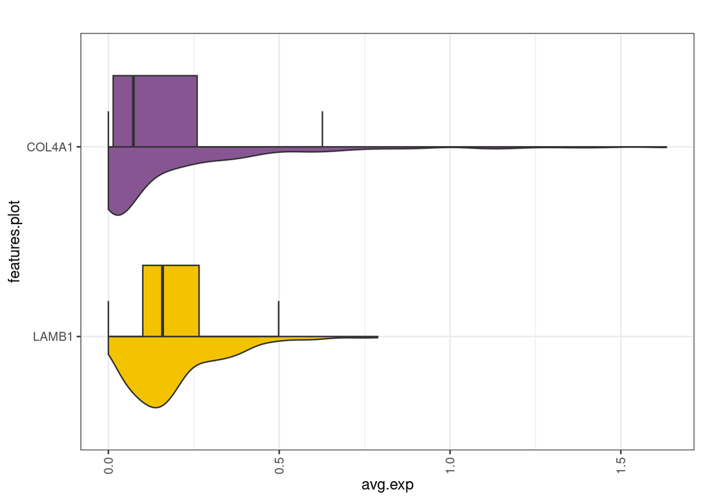

```r
 #saveWidget(DF_dt, file = "LAMB1_COL4A1_expression.html", title = "LAMB1,COL4A1 expression by cell line")


 p_1 <- ggplot(DF_orig, aes(x = features.plot, y = avg.exp, fill = features.plot)) +
   geom_half_violin(side = "l") +
   geom_half_boxplot(side = "r", outlier.color = NA) +
   #scale_y_continuous(trans='log10') +
   theme_bw() +
   theme(axis.text.x = element_text(angle = 90, vjust = 0.5, hjust=1)) +
   theme(legend.position="none") + labs(title = "") + scale_fill_manual(values = kelly()[3:length(kelly())]) +
   coord_flip()
 p_1
```

```r
# #### aggregate results for prostate cancer lines
#
# ## aggregate ranks only for prostate cancer lines (LNCAPCLONEFGC, PC3)
#
# ranked_list <- lapply(setNames(c("LNCAPCLONEFGC", "PC3"),c("LNCAPCLONEFGC", "PC3")), function(i){
#   r <- res %>% filter(Cell_line == i) %>% arrange(desc(score));
#   r$ID
# })
#
#
# # ranked_list <- lapply(setNames(c("LNCAPCLONEFGC", "PC3"),c("LNCAPCLONEFGC", "PC3")), function(i){
# #   r <- res %>% filter(Cell_line == i) %>% filter(score > 0.5) %>% arrange(desc(score));
# #   r$ID
# # })
#
#
# agg_res <- aggregate_ranks(ranked_list)
# # no significant results for aggregation!
# DT::datatable(agg_res)
#
#
#
# ## list the two prostate cancer line results separately
#
# ##LNCAPCLONEFGC
# lncap <- res %>% filter(score >= 0.5) %>% filter(Cell_line == "LNCAPCLONEFGC")
# DT::datatable(lncap)
#
# ##PC3
# pc3 <- res %>% filter(score >= 0.5) %>% filter(Cell_line == "PC3")
# DT::datatable(pc3)
#
# ggVennDiagram(list(pc3 = pc3$ID, lncap = lncap$ID), color = 1, lwd = 0.7) +
#  scale_fill_gradient(low = "#F4FAFE", high = "#4981BF") +
#  theme(legend.position = "none")
#
#
# ## get human protein atlas data
# #data(hpaCancer)
# #hpa_prostate <- hpaCancer %>% filter(Cancer == "prostate cancer")
# # unfavorable markers for prostate cancer
# #unfavorable_prostate <- hpa_prostate %>% filter(!is.na(prognostic.unfavorable) | !is.na(unprognostic.unfavorable) )
# ## found as ligands/receptors in significant signaling
# # none of the unfavorable markers is found in the list of signals (for bot PCa cell lines)
# # lapply(unique(res$Cell_line), function(x){
# #   r <- res %>% filter(score >= 0.5) %>% filter(Cell_line == x);
# #   sum(unfavorable_prostate$Gene.name %in% unique(c(r$ligand, lncap$receptor)))
# # })
# #
# # sum(unfavorable_prostate$Gene.name %in% unique(c(lncap$ligand, lncap$receptor)))
# # sum(unfavorable_prostate$Gene.name %in% unique(c(pc3$ligand, pc3$receptor)))
```

## PDX data

```r
#
#
# h5 <- Seurat::Read10X_h5("./../local/PDX_data/pdx_LNCaP_filtered_feature_bc_matrix_1.h5")
#
# sobj <- CreateSeuratObject(h5, min.cells = 1, min.features = 1)
#
# human_features <- rownames(sobj@assays[["RNA"]])[grep(pattern = "GRCh38",rownames(sobj@assays[["RNA"]]), invert = FALSE)]
# mouse_features <- rownames(sobj@assays[["RNA"]])[grep(pattern = "GRCm38",rownames(sobj@assays[["RNA"]]), invert = FALSE)]
#
# human_counts <- sobj@assays[["RNA"]]@counts[human_features,] %>% colSums()
# mouse_counts <- sobj@assays[["RNA"]]@counts[mouse_features,] %>% colSums()
#
# sobj@meta.data[["percent_mouse_counts"]] <- (mouse_counts / (human_counts + mouse_counts))
# DF <- data.frame(percent_mouse = sobj@meta.data[["percent_mouse_counts"]])
#
# ## as we would expect the cells have either predominent human or mouse aligned reads. only a small amount of cells fall in between. based on the histogram the cutoff value is set to 0.25, to be rather strict in removing potential mouse cells.
# ggplot(DF, aes(x = percent_mouse)) + geom_histogram(boundary = 0, binwidth = 0.02, fill = "black", colour = "white") +
#   theme_bw() + labs(title = "Percent of reads maped to the mouse reference")
#
# ## remove mouse cells
# object <- subset(sobj, subset = percent_mouse_counts <= 0.25)
#
# ## subset to only human features
# object <- object[human_features,]
#
# ## remove feature name "GRCh38-" from feature names (new seurat object has to be created)
#
# tmp_assay <- object@assays[["RNA"]]@counts
# tmp_meta_df <- object@meta.data
# new_feature_names <- sub(pattern = "^GRCh38-",replacement = "" ,x = rownames(tmp_assay))
# rownames(tmp_assay) <- new_feature_names
#
# object <- CreateSeuratObject(counts = tmp_assay, meta.data = tmp_meta_df)
#
# object <- object %>% NormalizeData()
#
# # calculate autocrine signaing
# cluster = rep(1, length(object$orig.ident))
# data=data.frame(object[['RNA']]@data)
# ## set s.score to 0 to keep all results, better for robust rank aggregation
# signal=cell_signaling(data=data,genes=row.names(object),cluster=cluster,int.type = "autocrine", species = "homo sapiens", s.score = 0, write = FALSE)
#
# pdx_res_signal <- signal[["cluster 1-cluster 1"]]
# colnames(pdx_res_signal)[1] <- "cluster1.1"
# colnames(pdx_res_signal)[2] <- "cluster1.2"
# pdx_res_signal <- pdx_res_signal %>% mutate(ID = paste0(cluster1.1, "_", cluster1.2))  %>% filter(LRscore > 0.5)
#
# ## Venn Diagram
# ggVennDiagram(list(pc3 = pc3$ID, lncap = lncap$ID, pdx = pdx_res_signal$ID), color = 1, lwd = 0.7) +
#  scale_fill_gradient(low = "#F4FAFE", high = "#4981BF") +
#  theme(legend.position = "none")
#
# ##
# TF_1 <- pdx_res_signal$ID %in% lncap$ID
# TF_2 <- pdx_res_signal$ID %in% pc3$ID
#
# ## In pdx and lncap but not pc3
#
# res <- pdx_res_signal[TF_1 & !(TF_2),]
# DT::datatable(res)
```